# Personalized Grit Lab Report

Updated March 5, 2021

Hi Zhao,

Welcome to your personalized Grit Lab report!

We will go week by week, reviewing everything you have told us through Poll Everywhere.

We hope this will help you reflect on what you learned and experienced during Grit Lab.

Important note!

Sometimes, you may not have been able to respond to all polls.

If the data for one of the polls is missing, the automatic report will display “NA” or "".

Okay, let’s get started!

The first half of Grit Lab delves deep into the passion component of Grit.

We like to call it “Choose Easy”, because we think gritty people pursue what they enjoy.

Putting it graphically, gritty people tend to pursue the intersection of these four circles.

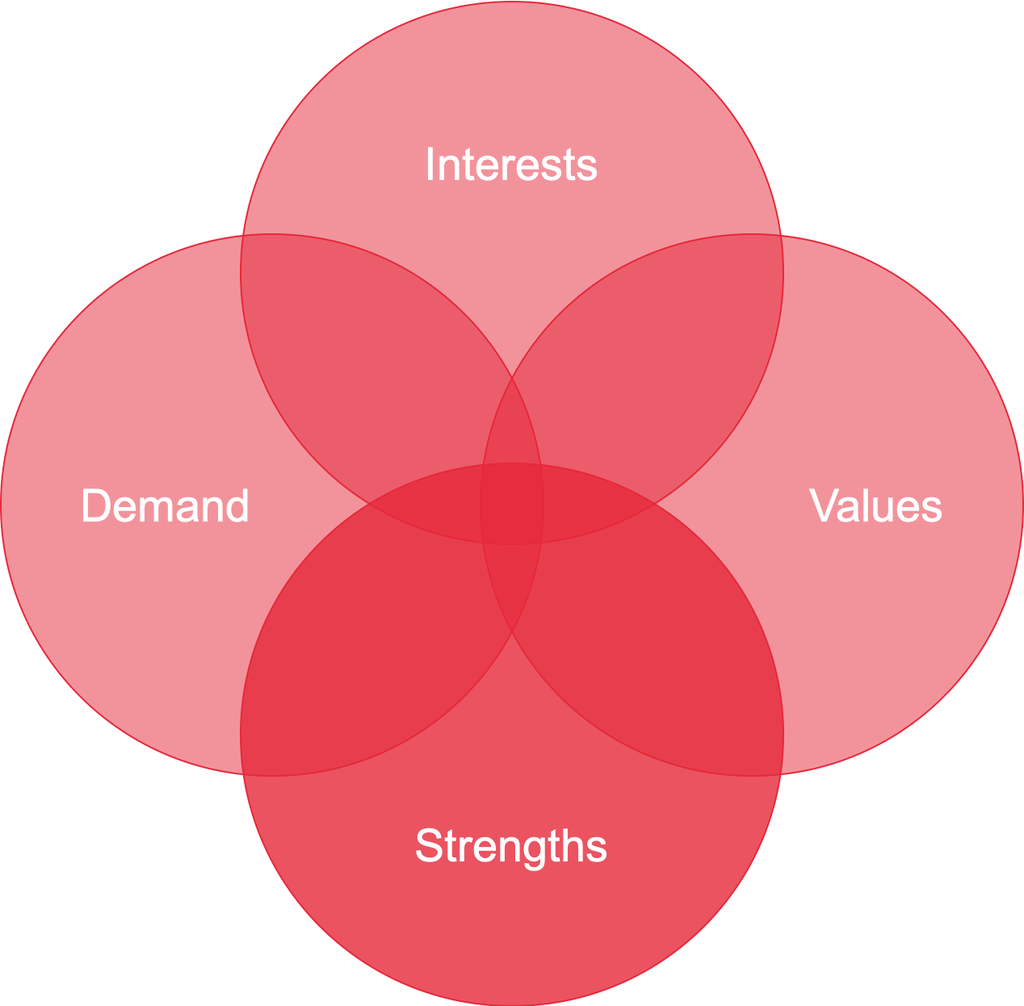

The first time we met, you told us where you were on the grit rubric.

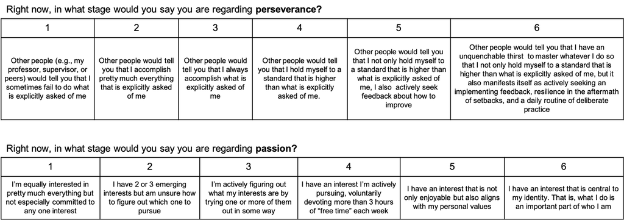

Regarding passion you picked Stage 3: I’m actively figuring out what my interests are by trying one or more of them out in some way.

Regarding perseverance you picked Stage 5: Other people would tell you that I not only hold myself to a standard that is higher than what is explicitly asked of me, I also actively seek feedback about how to improve.

This chart shows how you rated yourself on a 1 - 6 scale.

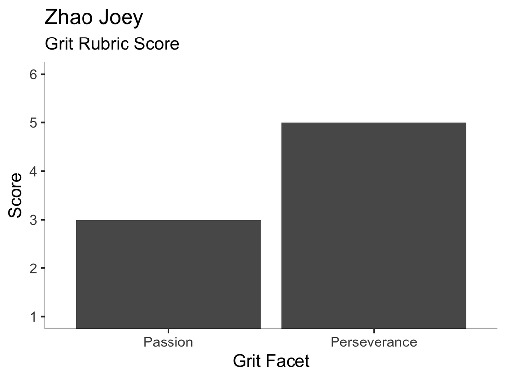

As you know, grit grows, so don’t worry if you are not yet where you’d like to be in your grit development.

Hopefully, this class will help you become grittier each day.

On week 2 we looked at your interests.

Interest is an emotion, and it is the opposite of boredom.

Your interests are the activities or subjects that spontaneously grab your attention.

Trying things out and seeing how you feel is the best way to refine your interests.

Here is the quote you wrote to summarize this class.

"“I read to grow, not to ossify it”"

On week 3, we studied values, your beliefs about what is important.

You said your top three values were self-direction, benevolence, and achievement.

Here is the quote you wrote to summarize this class.

"“I can’t solve any problem unless I’m honest about the problem”, More empathy and understanding for where the other person is coming from even if we might not necessarily agree I think will make the world a better place"

You wrote a “This I Believe” essay, and here’s where you located it on Schwartz’s value taxonomy.

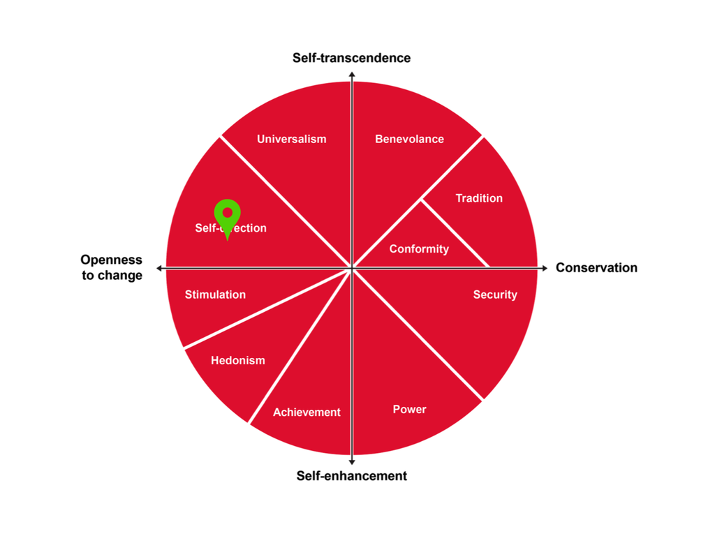

When we talked about strengths on week 4, you said your personality strength was agreeableness.

You said your top three talents were analytic, social, and artistic / spatial.

Here is the quote you wrote to summarize this class.

"“You’re different even from yourself”"

We then talked about goal hierarchies.

Here’s how you said you felt about your top-level goal.

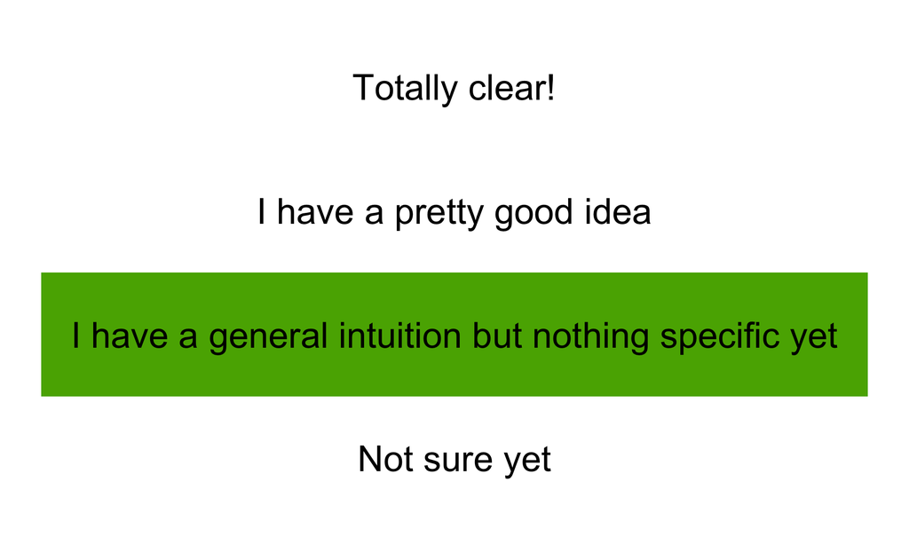

We discussed self-concordance, or how much a goal aligns to your deeply held values and beliefs.

A goal you said you will be pursuing for the next six months is to getting an internship, living internationally.

Here is how self-concordant that goal was, compared to the rest of the class.

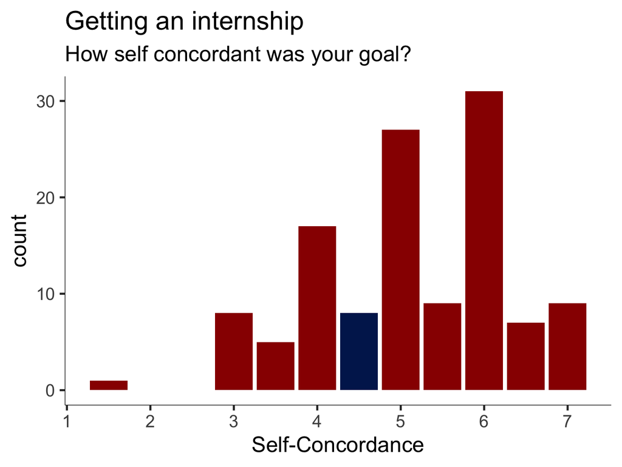

You are in the blue bar!

Don’t worry if your self-concordance for that particular goal is low.

It might mean that you need to reframe that goal in a way that makes it more relevant to your deep self, or change it!

Remember that self-concordance is goal specific, so other goals might be more self-concordant.

Here is the quote you wrote to summarize this class.

"“Sometimes we ask too much of our 9 to 5 job”, “Talk about your goal with everyone so it feels like you have to do it now” LOL"

We then transitioned to the second part of Grit Lab:

Work smart

On week 6 we looked at goal setting and planning.

You WOOPed!

Wish: What do you want to accomplish. You said:

“Apply to 20 internship opportunities”

Outcome: What would happen if your wish came true. You said:

“Feeling more on track to get a summer internship”

Obstacle: What, that’s within you, stands in your way. You said:

“procrastination, feeling inadequate and unqualified, lack of motivation”

Plan: What is your when-then plan to achieve the goal. You said:

“When it is Saturday at 10pm, then I will be sitting at my desk applying for internships straight for at least an hour.”

Here’s how it went

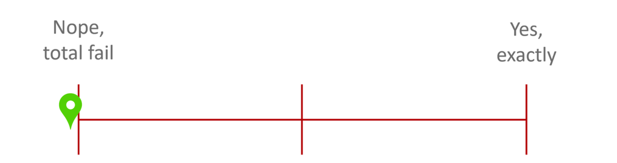

And here’s how much you learned.

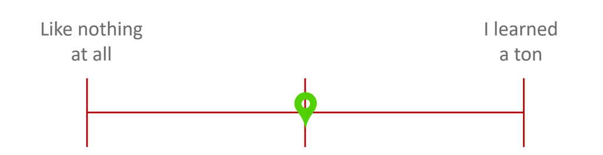

Hopefully you learned, regardless of how it went!

Here is the quote you wrote to summarize this class.

""

On week 7 we talked about deliberate practice.

You told us you had practiced violin, cooking, calligraphy, dancing.

We learned that deliberate practice requires a challenging, hyperspecific goal, maximum concentration, instant feedback, and is often done alone.

Here is the quote you wrote to summarize this class.

""

On week 8, we discussed feedback.

Even though feedback can be hard to take, it is often the key to improve. So if you want to improve, seek it actively!

You said you felt defensive, unresponsive, receptive when receiving critical feedback, and neutral, happy, appreciated when receiving positive feedback.

Regarding your practice, you received feedback short delay, after a long delay, and felt that it was mostly helpful.

Here is the quote you wrote to summarize this class.

""

We then turned to learning about stress.

In week nine, you reported feeling a lot of stress in your life right now, the primary source of it being school, summer plans, asian hate crimes, friendships, relationships, socializing, future.

We also talked about adversity and failure.

Although related, adversity and failure are different:

Adversity happens to us, whereas failure is something for which we are generally more responsible.

However, how we interpret stress and failure matters…

You said that you believe it is that the effects of stress are negative and should be avoided,

…and that it is true that stress facilitates learning and growth.

Interestingly, research has found that people who believe that **stress can facilitate learning and growth** experience enhanced **performance, well-being and health.**

Here is the quote you wrote to summarize this class.

""

In week 10 we looked at mentors: role models that take an active role in your growth.

Hopefully, your mentor was authoritative, being *both* supportive *and* demanding.

Here’s how you described them.

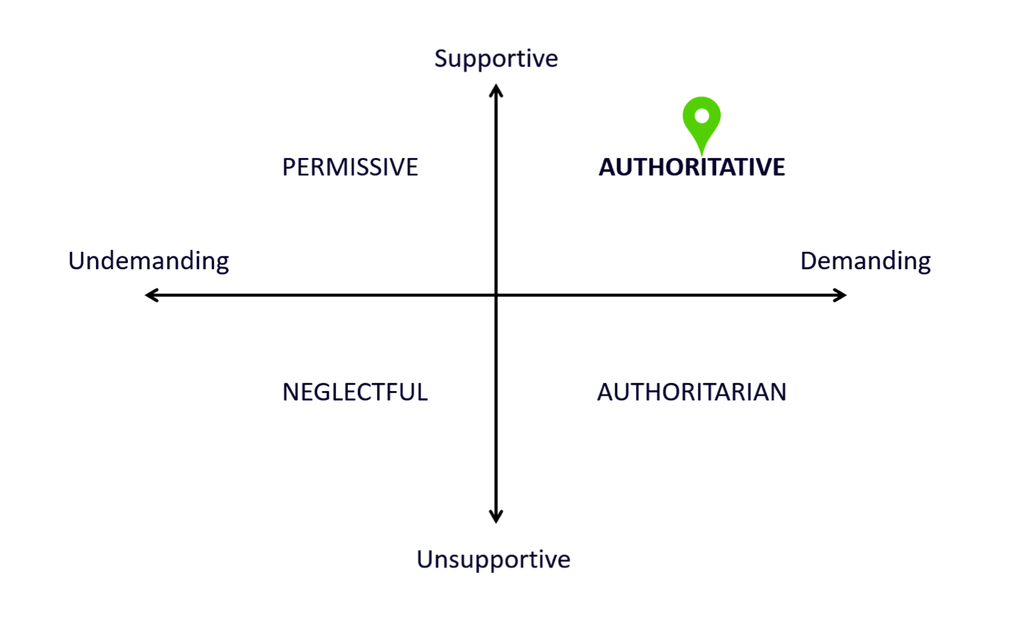

You also wrote a gratitude letter to parent. Do you remember what you said and how it made you feel?

Here is the quote you wrote to summarize this class.

“I’m giving you these comments because I have high expectations and I know you can reach them”

We closed the work smart section of the class by talking about habits.

You tried setting a morning routine that you were able to keep up for three days.

Having a deliberate practice habit is a predictor of consistent improvement. You said you’ve had a daily practice habit in sports, music, journaling

Here is the quote you wrote to summarize this class.

“Don’t ask yourself to try harder, you already are. Instead, try to change the situation”

Finally, what good is grit if we do not dream for others? In the penultimate class, we looked at paying it forward.

We learned about givers, matchers and takers. You endorsed Giver values.

One way of paying it forward is having a prosocial, beyond-the-self purpose. Here’s how you responded to items assessing that.

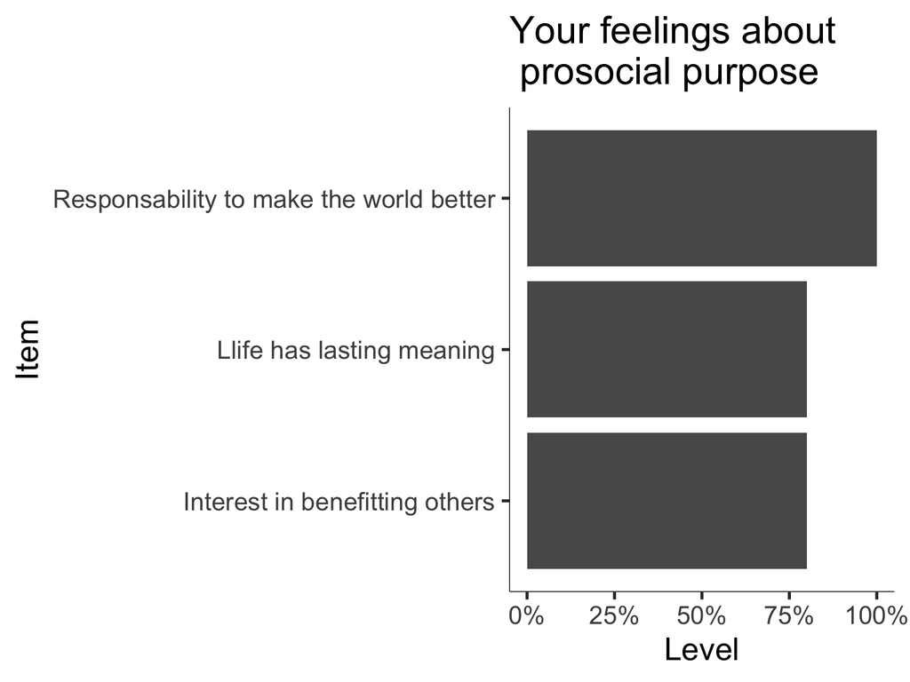

Here is the quote you wrote to summarize this class.

“You must act as if it’s impossible to fail”

… and so quickly we arrived at the end of the semester.

Here’s how your mood evolved through the weeks.

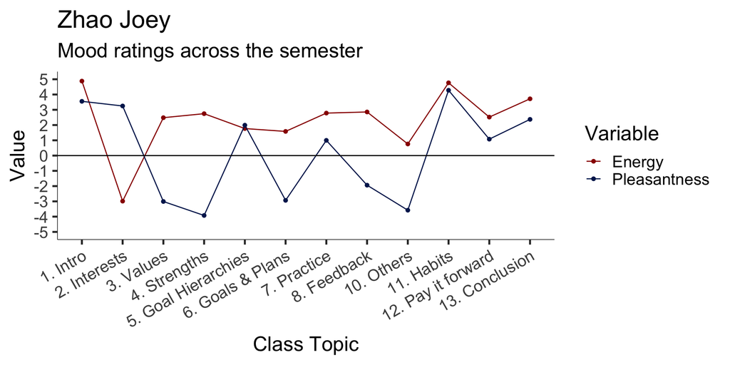

Do you notice any patterns? Is there anything that correlates with your mood?

Here are all the questions you’ve had throughout the semester.

| Class | Question |
| --- | --- |
| 1. Intro | Is everyone able to become grittier or is it dependent on certain characteristics and personalities? |
| 2. Interests | We'll probably cover this later but how do we know when we're interested in something? |
| 3. Values | How do you know if your values are actually your values and not what you want your values to be? |
| 4. Strengths | how do you know when you are heading towards a career that will be a good fit? Or will you only know after dabbling in it for some time? |
| 5. Goal Hierarchies | What is the line between thinking too much and thinking just enough? |
| 11. Habits | Sometimes I fall into the transactional mindset of if I keep doing things for others, there is a feeling inside that wants something in return, is there a way to change this transactional mindset and … |
| 12. Pay it forward | How do we find the difference we can make in the world? |

On the final class, we reviewed everything and looked back to how our passion and perseverance evolved during this class.

After all this time, we hope you have emerged from Grit Lab a little grittier than you started.

Do you want to see how your grit rubric changed?

Drumroll please…

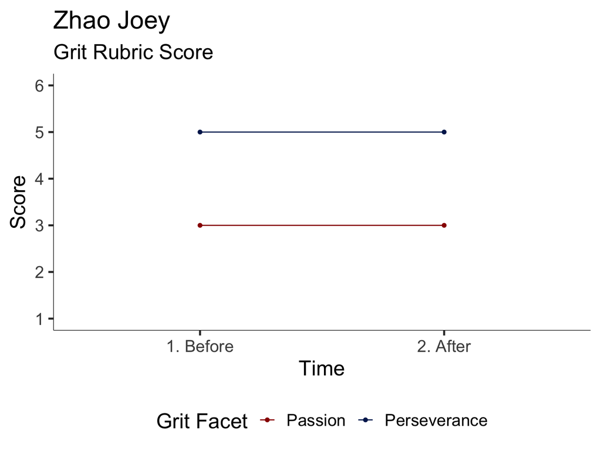

Don’t worry if the rubric doesn’t yet reflect growth. It is only a coarse measure that cannot replace your own self-reflection.

In any case, grit is not built in a day…

…so stay passionate and persevering in the lifelong quest of choosing easy, working hard, and paying it forward.

With grit and gratitude,

Angela and the Grit Lab team.